# Team

Joel Martin

9/23/2020

## Lab 3

I decided to work on my own for Lab 3. This is a report of my findings.

First I thought it was important to change the column names to make it easier when I needed to access them throughout the lab.

```
## # A tibble: 6 x 8
##   gss_year    id marital_status highest_year_of~ sex   party_affiliati~
##      <dbl> <dbl> <chr>          <chr>            <chr> <chr>
## 1     1972     1 Never married  16               Fema~ Ind,near dem
## 2     1972     2 Married        10               Male  Not str democrat
## 3     1972     3 Married        12               Fema~ Independent
## 4     1972     4 Married        17               Fema~ Not str democrat
## 5     1972     5 Married        12               Fema~ Strong democrat
## 6     1972     6 Never married  14               Male  Ind,near dem
## # ... with 2 more variables: general_happiness <chr>,
## #   ballot_used_for_interview <chr>
```

## Question 1

Changed highest year of school column to numeric. This caused values of ‘no answer’ in the column to become na making it easier to remove them. Then I removed na and grouped by party affiliation and found the mean of highest year of school complete.

```
## # A tibble: 10 x 2
##    party_affiliation  averageEducation
##    <chr>                         <dbl>
##  1 Don't know                     10.9
##  2 Ind,near dem                   13.2
##  3 Ind,near rep                   13.3
##  4 Independent                    12.3
##  5 No answer                      12.3
##  6 Not str democrat               12.6
##  7 Not str republican             13.3
##  8 Other party                    13.4
##  9 Strong democrat                12.5
## 10 Strong republican              13.4
```

It is hard to draw conclusions or see any patterns as each group has similar average of education levels.

## Question 2

Did similar data cleaning as in beginning of question 1. Then joined q2dat and q1dat to get the mean education level for each party for each person in q2dat. Then found the individuals whose education level was higher than their political party affiliation mean.

```
## tibble [27,842 x 9] (S3: tbl_df/tbl/data.frame)
##  $ gss_year                 : num [1:27842] 1972 1972 1972 1972 1972 ...
##  $ id                       : num [1:27842] 1 4 6 8 11 16 17 19 20 25 ...
##  $ marital_status           : chr [1:27842] "Never married" "Married" "Never married" "Never married" ...
##  $ highest_year_of_school   : num [1:27842] 16 17 14 16 13 14 14 17 14 16 ...
##  $ sex                      : chr [1:27842] "Female" "Female" "Male" "Male" ...
##  $ party_affiliation        : chr [1:27842] "Ind,near dem" "Not str democrat" "Ind,near dem" "Ind,near dem" ...
##  $ general_happiness        : chr [1:27842] "Not too happy" "Not too happy" "Pretty happy" "Not too happy" ...
##  $ ballot_used_for_interview: chr [1:27842] "Not applicable" "Not applicable" "Not applicable" "Not applicable" ...
##  $ averageEducation         : num [1:27842] 13.2 12.6 13.2 13.2 12.5 ...
```

## Question 3

Selected only marital status and general happiness from dat to look at and then created a stacked bar graph showing the percentage of happiness in each marital status group by general happiness.

```
##  marital_status     general_happiness
##  Length:64816       Length:64816
##  Class :character   Class :character
##  Mode  :character   Mode  :character
```

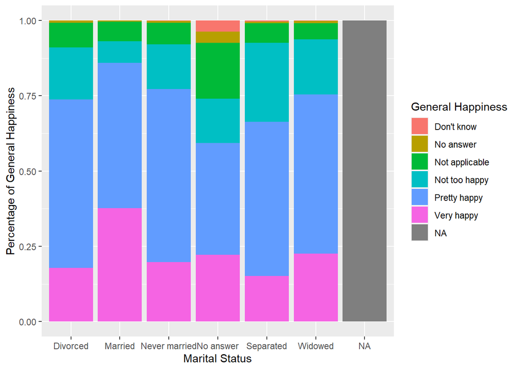

Based on the graph it appears that those who are married are generally more happy compared to those in the other marital status columns. Overall though most groups except for the no answer group is generally happy.

## Question 4

Used facet wrap to show multiple graphs, one for each category in party affiliation.

```
##  marital_status     general_happiness  party_affiliation
##  Length:64816       Length:64816       Length:64816
##  Class :character   Class :character   Class :character
##  Mode  :character   Mode  :character   Mode  :character
```

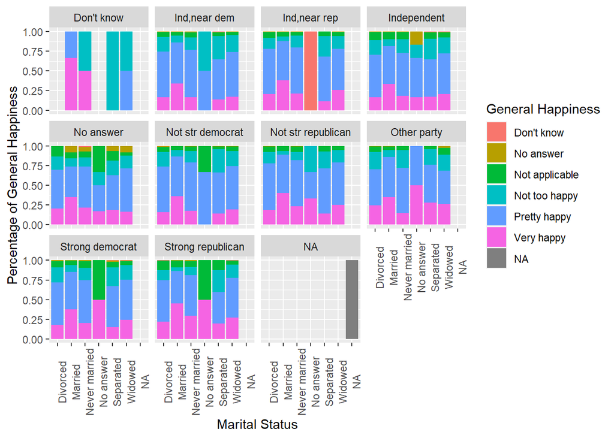

It appears between the opposite graphs (ex. Strong Republican vs Strong Democrat, Not Str Republican vs. Not Str Democrat) that there is little change and hardly any correlation that party affiliation affects marital status to general happiness.

## Question 5

Created a table containing only marital status and highest year of school. Turned highest year of school column into a numeric column to be able to better display the data. Ordered the table by highest year of school and created a graph showing relation between marital status and highest year of school completed.

```
##  marital_status     highest_year_of_school
##  Length:64816       Min.   : 0.00
##  Class :character   1st Qu.:12.00
##  Mode  :character   Median :12.00
##                     Mean   :12.87
##                     3rd Qu.:15.00
##                     Max.   :20.00
##                     NA's   :179
```

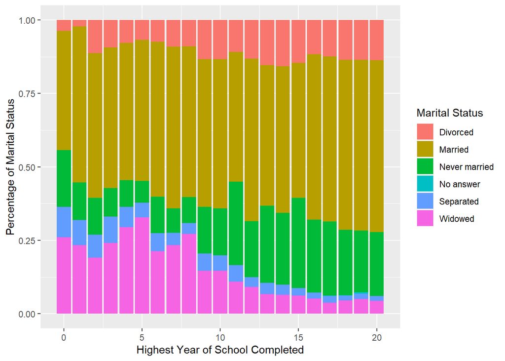

It appears that those who didn’t get past elementary school (0-8) they are less likely to be divorced, more likely to be widowed and less likely to have never married. It’s possible that they are an older generation since they’re more likely to have gotten married and also be widowed. Also they are less likely to have gotten divorced as that was looked down upon back then.

For those who completed high school and above, it appears that they are the opposite of the first group they’re less likely to have gotten married and also be widowed. Also they are more likely to have gotten divorced.

## Question 6

## Part A

The first question I want to look at is how the individuals sex compares to level of education obtained. Created a new data set containing highest year of school and sex. Turned highest year of school column into a numeric column. Created a graph showing relation between highest year of school completed and sex.

```
##  highest_year_of_school     sex
##  Min.   : 0.00          Length:64816
##  1st Qu.:12.00          Class :character
##  Median :12.00          Mode  :character
##  Mean   :12.87
##  3rd Qu.:15.00
##  Max.   :20.00
##  NA's   :179
```

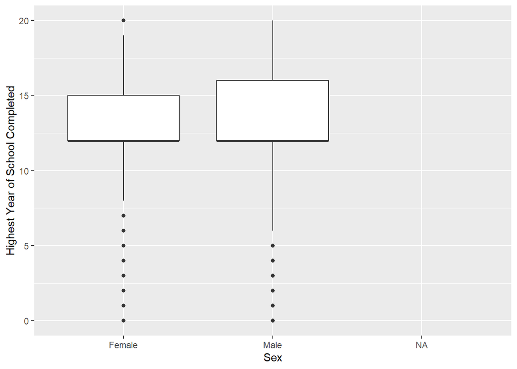

It appears that the average education level of male and females is about the same at about 12 years which would equal a high school diploma. However it looks like males are slightly more likely to pursue a higher education.

## Part B

The second question I want to look at is how general happiness has changed over the years.

```
##     gss_year    general_happiness
##  Min.   :1972   Length:64816
##  1st Qu.:1984   Class :character
##  Median :1996   Mode  :character
##  Mean   :1995
##  3rd Qu.:2006
##  Max.   :2018
##  NA's   :2
```

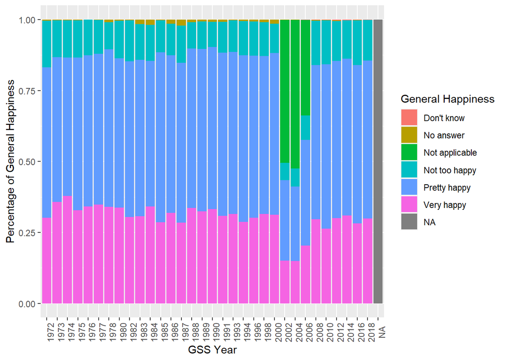

Overall it appears that people are generally happy and there is little change in the data except between 2000 - 2006. Here there are a number of individuals who responded Not Applicable as an answer to their general happiness. It is unclear as to why this is.